# Cargar base de datos

```python
# Importar Librerías
import os
import pandas as pd
import numpy as np
from scipy import stats
import matplotlib.pyplot as plt
import seaborn as sns
from sklearn.metrics import confusion_matrix, ConfusionMatrixDisplay

# Obtener la ruta del directorio actual
current_directory = os.path.dirname(_file) if "file_" in locals() else os.getcwd()

# Construir la ruta al archivo xlsx
file_path = os.path.join(current_directory, 'base.xlsx')

# Cargar el archivo xlsx en un DataFrame
df = pd.read_excel(file_path)
```

# Ajuste Modelo Árboles de Decisión

```python
# Primer paso: dividir las columnas en dos tipos de variables: dependientes e independientes
var_indep = ['job', 'marital', 'education', 'default','balance','housing','loan','contact','day','month','duration','campaign','pdays','previous','poutcome']
X = df[var_indep] # Variables Independientes
# Al tener variables categóricas, se convierten a numéricas
X = pd.get_dummies(X, drop_first=True)

y = df.y # Variable Objetivo
# La variable dependiente 'y' es categórica como 'yes' o 'no', por lo que se convierte a valores binarios
y = y.map({'no': 0, 'yes': 1})
```

```python
# Segundo paso: Dividir base de datos en conjunto de entrenamiento y de prueba

# Se dividen X y y en los sets de entrenamiento y de prueba
import pandas as pd
import numpy as np
import matplotlib.pyplot as plt
import seaborn as sns
from sklearn.model_selection import train_test_split
from sklearn.model_selection import RandomizedSearchCV
from sklearn.datasets import load_iris
import pandas as pd
import numpy as np
from sklearn import tree
from tabulate import tabulate
import matplotlib.pyplot as plt


# Se usa un radio de 75:25, es decir, 75% de los datos va a ser usados en el modelo de entrenamiento y 25% para el modelo de prueba
X_train, X_test, y_train, y_test = train_test_split(X, y, test_size=0.25, random_state=16)
```

```python
# versión que optimiza la métrica de accuracy sin parámetros
modelo = tree.DecisionTreeClassifier()

modelo_optimo = RandomizedSearchCV(estimator = modelo,
                                        param_distributions = dict(),
                                        n_iter = 10,
                                        cv = 5,
                                        verbose=  2,
                                        random_state = 42,
                                        n_jobs = -1,
                                        scoring = None)

modelo_optimo.fit(X_train, y_train)

modelo = modelo_optimo.best_estimator_

modelo.fit(X_train, y_train)

print(f"Mejores hiperparámetros: {modelo_optimo.best_params_}")
print(f"Mejor puntuación: {modelo_optimo.best_score_}")
```

```
Fitting 5 folds for each of 1 candidates, totalling 5 fits
Mejores hiperparámetros: {}
Mejor puntuación: 0.8777575172636816
```

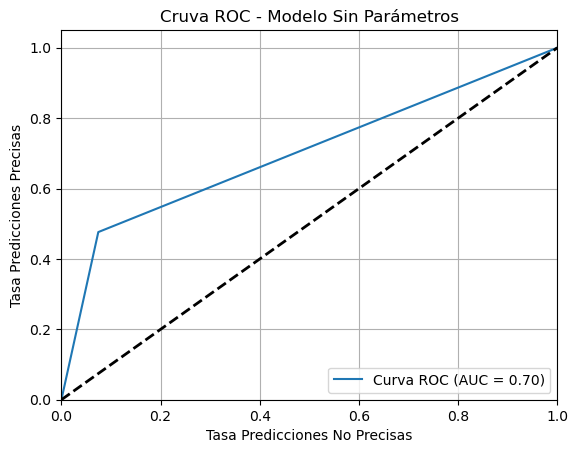

```python
# Graficar curva ROC
from sklearn.metrics import roc_curve, auc
from sklearn.preprocessing import label_binarize

y_pred = modelo.predict_proba(X_test)[:,1]
fpr, tpr, _ = roc_curve(y_test, y_pred)
roc_auc = auc(fpr, tpr)

plt.figure()
plt.plot(fpr, tpr, label="Curva ROC (AUC = {:.2f})".format(roc_auc))
plt.plot([0, 1], [0, 1], color='black', lw=2, linestyle='--')
plt.xlim([0.0, 1.0])
plt.ylim([0.0, 1.05])
plt.xlabel('Tasa Predicciones No Precisas')
plt.ylabel('Tasa Predicciones Precisas')
plt.title('Cruva ROC - Modelo Sin Parámetros')
plt.legend(loc='lower right')
plt.grid()
plt.show()
```

```python
# versión que optimiza la métrica de accuracy, pero con parámetros

from scipy.stats import randint, uniform
param_distributions = dict(
    max_depth = randint(1, 5),
    ccp_alpha = uniform()
)

modelo_cal = tree.DecisionTreeClassifier()
modelo_optimo_cal = RandomizedSearchCV(estimator = modelo_cal,
                                        param_distributions = param_distributions,
                                        n_iter = 10,
                                        cv = 5,
                                        verbose=  2,
                                        random_state = 42,
                                        n_jobs = -1,
                                        scoring = None)

modelo_optimo_cal.fit(X_train, y_train)

modelo_cal = modelo_optimo_cal.best_estimator_

modelo_cal.fit(X_train, y_train)

print(f"Mejores hiperparámetros: {modelo_optimo_cal.best_params_}")
print(f"Mejor puntuación: {modelo_optimo_cal.best_score_}")
```

```
Fitting 5 folds for each of 10 candidates, totalling 50 fits
Mejores hiperparámetros: {'ccp_alpha': 0.0007787658410143283, 'max_depth': 4}
Mejor puntuación: 0.900613332715211
```

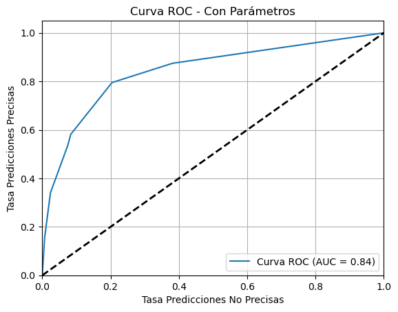

```python
# Graficar curva ROC
y_pred_prob = modelo_cal.predict_proba(X_test)[:,1]
fpr_cal, tpr_cal, _ = roc_curve(y_test, y_pred_prob)
roc_auc_cal = auc(fpr_cal, tpr_cal)

plt.figure()
plt.plot(fpr_cal, tpr_cal, label="Curva ROC (AUC = {:.2f})".format(roc_auc_cal))
plt.plot([0, 1], [0, 1], color='black', lw=2, linestyle='--')
plt.xlim([0.0, 1.0])
plt.ylim([0.0, 1.05])
plt.xlabel('Tasa Predicciones No Precisas')
plt.ylabel('Tasa Predicciones Precisas')
plt.title('Curva ROC - Con Parámetros')
plt.legend(loc='lower right')
plt.grid()
plt.show()
```

0.84 significa que tiene buena capacida discriminativa, comparado con el anterior distingue mucho mejor entre positivos y negativos. La curva se acerca mucho al borde superior, lo cual es ideal e indica que logra una alta tasa de verdaderos positivos, sin elevar demasiado la tasa de falsos positivos. El optimizador probablemente encontró hiperparámetros que generalizan mejor y no sobreajustan al conjunto de entrenamiento, lo que puede ser indicativo de que el dataset tiene desequilibrio de clases, y optimizar por accuracy no penalizaba adecuadamente los falsos positivos.

```python
# versión que optimiza la métrica de F1 Score

modelo_f1 = tree.DecisionTreeClassifier()
modelo_optimo_f1 = RandomizedSearchCV(estimator = modelo_f1,
                                        param_distributions = param_distributions,
                                        n_iter = 10,
                                        cv = 5,
                                        verbose=  2,
                                        random_state = 42,
                                        n_jobs = -1,
                                        scoring = "f1_weighted")

modelo_optimo_f1.fit(X_train, y_train)

modelo_f1 = modelo_optimo_f1.best_estimator_

modelo_f1.fit(X_train, y_train)

print(f"Mejores hiperparámetros: {modelo_optimo_f1.best_params_}")
print(f"Mejor puntuación: {modelo_optimo_f1.best_score_}")
```

```
Fitting 5 folds for each of 10 candidates, totalling 50 fits
Mejores hiperparámetros: {'ccp_alpha': 0.0007787658410143283, 'max_depth': 4}
Mejor puntuación: 0.8869993198343534
```

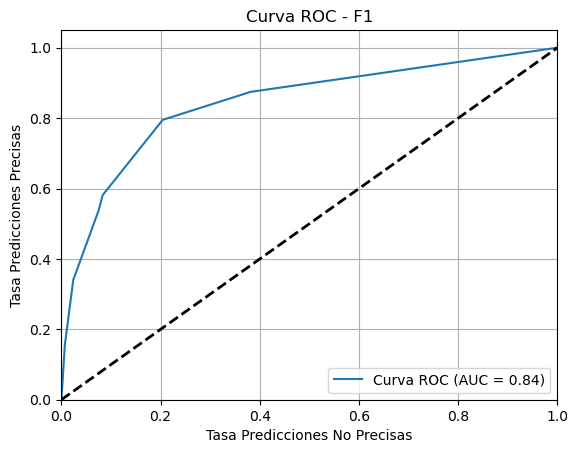

```python
# Graficar curva ROC
y_pred_prob_f1 = modelo_f1.predict_proba(X_test)[:,1]
fpr_f1, tpr_f1, _ = roc_curve(y_test, y_pred_prob_f1)
roc_auc_f1 = auc(fpr_f1, tpr_f1)

plt.figure()
plt.plot(fpr_f1, tpr_f1, label="Curva ROC (AUC = {:.2f})".format(roc_auc_f1))
plt.plot([0, 1], [0, 1], color='black', lw=2, linestyle='--')
plt.xlim([0.0, 1.0])
plt.ylim([0.0, 1.05])
plt.xlabel('Tasa Predicciones No Precisas')
plt.ylabel('Tasa Predicciones Precisas')
plt.title('Curva ROC - F1')
plt.legend(loc='lower right')
plt.grid()
plt.show()
```

```python
# versión que optimiza la métrica de precision

modelo_p = tree.DecisionTreeClassifier()
modelo_optimo_p = RandomizedSearchCV(estimator = modelo_p,
                                        param_distributions = param_distributions,
                                        n_iter = 10,
                                        cv = 5,
                                        verbose=  2,
                                        random_state = 42,
                                        n_jobs = -1,
                                        scoring = "precision_weighted")

modelo_optimo_p.fit(X_train, y_train)

modelo_p = modelo_optimo_p.best_estimator_

modelo_p.fit(X_train, y_train)

print(f"Mejores hiperparámetros: {modelo_optimo_p.best_params_}")
print(f"Mejor puntuación: {modelo_optimo_p.best_score_}")
```

```
Fitting 5 folds for each of 10 candidates, totalling 50 fits
Mejores hiperparámetros: {'ccp_alpha': 0.0007787658410143283, 'max_depth': 4}
Mejor puntuación: 0.8851331279124958
```

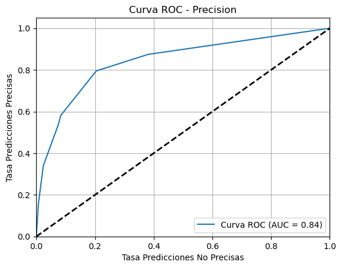

```python
# Graficar curva ROC
y_pred_prob_p = modelo_p.predict_proba(X_test)[:,1]
fpr_p, tpr_p, _ = roc_curve(y_test, y_pred_prob_p)
roc_auc_p = auc(fpr_p, tpr_p)

plt.figure()
plt.plot(fpr_p, tpr_p, label="Curva ROC (AUC = {:.2f})".format(roc_auc_p))
plt.plot([0, 1], [0, 1], color='black', lw=2, linestyle='--')
plt.xlim([0.0, 1.0])
plt.ylim([0.0, 1.05])
plt.xlabel('Tasa Predicciones No Precisas')
plt.ylabel('Tasa Predicciones Precisas')
plt.title('Curva ROC - Precision')
plt.legend(loc='lower right')
plt.grid()
plt.show()
```

```python
# versión que optimiza la métrica de recall

modelo_r = tree.DecisionTreeClassifier()
modelo_optimo_r = RandomizedSearchCV(estimator = modelo_r,
                                        param_distributions = param_distributions,
                                        n_iter = 10,
                                        cv = 5,
                                        verbose=  2,
                                        random_state = 42,
                                        n_jobs = -1,
                                        scoring = "recall_weighted")

modelo_optimo_r.fit(X_train, y_train)

modelo_r = modelo_optimo_r.best_estimator_

modelo_r.fit(X_train, y_train)

print(f"Mejores hiperparámetros: {modelo_optimo_r.best_params_}")
print(f"Mejor puntuación: {modelo_optimo_r.best_score_}")
```

```
Fitting 5 folds for each of 10 candidates, totalling 50 fits
Mejores hiperparámetros: {'ccp_alpha': 0.0007787658410143283, 'max_depth': 4}
Mejor puntuación: 0.900613332715211
```

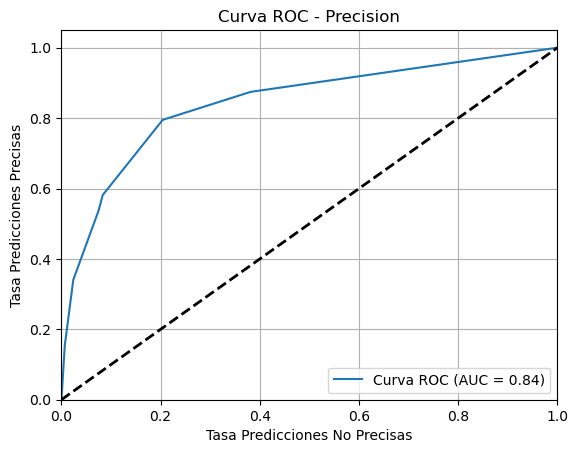

```python
# Graficar curva ROC
y_pred_prob_r = modelo_r.predict_proba(X_test)[:,1]
fpr_r, tpr_r, _ = roc_curve(y_test, y_pred_prob_r)
roc_auc_r = auc(fpr_r, tpr_r)

plt.figure()
plt.plot(fpr_r, tpr_r, label="Curva ROC (AUC = {:.2f})".format(roc_auc_r))
plt.plot([0, 1], [0, 1], color='black', lw=2, linestyle='--')
plt.xlim([0.0, 1.0])
plt.ylim([0.0, 1.05])
plt.xlabel('Tasa Predicciones No Precisas')
plt.ylabel('Tasa Predicciones Precisas')
plt.title('Curva ROC - Precision')
plt.legend(loc='lower right')
plt.grid()
plt.show()
```

```python
#Se procede a evaluar el modelo
from sklearn.metrics import accuracy_score, precision_score, recall_score, f1_score

# Diccionario para almacenar resultados
resultados = {}

# Modelo sin calibrar
resultados['modelo'] = {
    'Accuracy': accuracy_score(y_test, y_pred),
    'Precision': precision_score(y_test, y_pred, average='weighted'),
    'Recall': recall_score(y_test, y_pred, average='weighted'),
    'F1 Score': f1_score(y_test, y_pred, average='weighted')
}

# Modelo calibrado
y_pred_cal = modelo_cal.predict(X_test)
resultados['modelo_cal'] = {
    'Accuracy': accuracy_score(y_test, y_pred_cal),
    'Precision': precision_score(y_test, y_pred_cal, average='weighted'),
    'Recall': recall_score(y_test, y_pred_cal, average='weighted'),
    'F1 Score': f1_score(y_test, y_pred_cal, average='weighted')
}

# Modelo F1
y_pred_f1 = modelo_f1.predict(X_test)
resultados['modelo_f1'] = {
    'Accuracy': accuracy_score(y_test, y_pred_f1),
    'Precision': precision_score(y_test, y_pred_f1, average='weighted'),
    'Recall': recall_score(y_test, y_pred_f1, average='weighted'),
    'F1 Score': f1_score(y_test, y_pred_f1, average='weighted')
}

# Modelo Precision
y_pred_p = modelo_p.predict(X_test)
resultados['modelo_precision'] = {
    'Accuracy': accuracy_score(y_test, y_pred_p),
    'Precision': precision_score(y_test, y_pred_p, average='weighted'),
    'Recall': recall_score(y_test, y_pred_p, average='weighted'),
    'F1 Score': f1_score(y_test, y_pred_p, average='weighted')
}

# Modelo Precision
y_pred_r = modelo_r.predict(X_test)
resultados['modelo_recall'] = {
    'Accuracy': accuracy_score(y_test, y_pred_r),
    'Precision': precision_score(y_test, y_pred_r, average='weighted'),
    'Recall': recall_score(y_test, y_pred_r, average='weighted'),
    'F1 Score': f1_score(y_test, y_pred_r, average='weighted')
}

# Convertir a DataFrame
df_resultados = pd.DataFrame(resultados).T
df_resultados
```

|  | Accuracy | Precision | Recall | F1 Score |
| --- | --- | --- | --- | --- |
| modelo | 0.871096 | 0.871948 | 0.871096 | 0.871518 |
| modelo_cal | 0.898965 | 0.884099 | 0.898965 | 0.884397 |
| modelo_f1 | 0.898965 | 0.884099 | 0.898965 | 0.884397 |
| modelo_precision | 0.898965 | 0.884099 | 0.898965 | 0.884397 |
| modelo_recall | 0.898965 | 0.884099 | 0.898965 | 0.884397 |

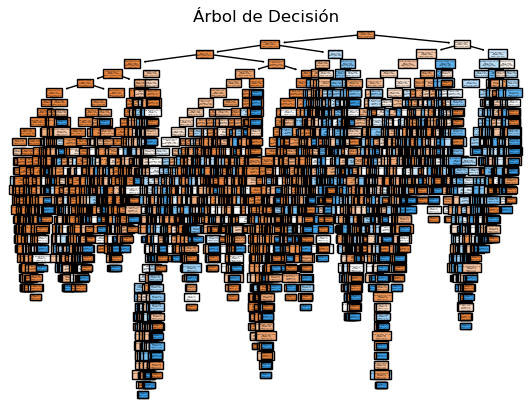

```python
plt.figure()
tree.plot_tree(modelo, filled=True, feature_names=X.columns, class_names=True)
plt.title("Árbol de Decisión")
plt.show()
```

Extremadamente profundo y complejo, puede ajustarse demasiado a los datos de entrenamiento. Aunque tiene buena performance en entrenamiento, su complejidad lo hace poco interpretativo y potencialmente inestable en datos nuevos.

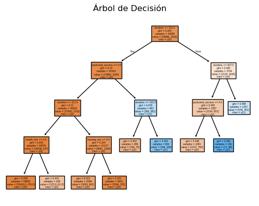

```python
plt.figure()
tree.plot_tree(modelo_cal, filled=True, feature_names=X.columns, class_names=True)
plt.title("Árbol de Decisión")
plt.show()
```

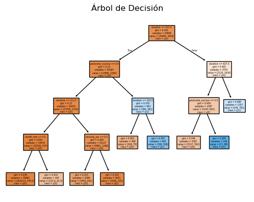

```python
plt.figure()
tree.plot_tree(modelo_f1, filled=True, feature_names=X.columns, class_names=True)
plt.title("Árbol de Decisión")
plt.show()
```

Que sea casi idéntico al anterior confirma que el conjutno de hiperparámetros óptimos encontrados fue el mismo en ambos casos.

## Se va a usar el modelo_f1

```python
importancias = modelo_f1.feature_importances_
variables = X.columns
df_importancia = pd.DataFrame({'Variable': variables, 'Importancia': importancias})
df_importancia = df_importancia.sort_values(by='Importancia', ascending=False)

# Mostrar
print(df_importancia)
```

```
               Variable  Importancia
2              duration     0.604585
39     poutcome_success     0.325125
23          housing_yes     0.051969
33            month_mar     0.018322
0               balance     0.000000
30            month_jan     0.000000
24             loan_yes     0.000000
25    contact_telephone     0.000000
26      contact_unknown     0.000000
27            month_aug     0.000000
28            month_dec     0.000000
29            month_feb     0.000000
32            month_jun     0.000000
31            month_jul     0.000000
```

[output cut: 27 more lines]

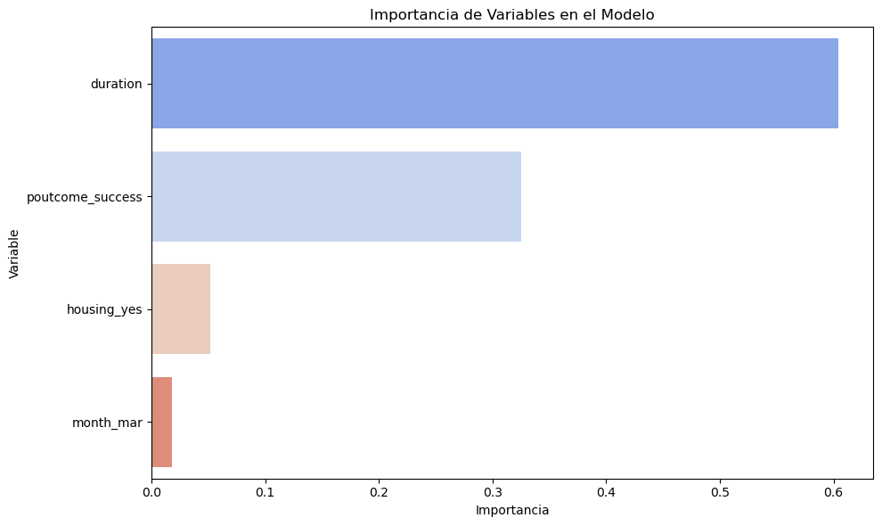

```python
# Filtrar solo variables con importancia > 0
df_filtrado = df_importancia[df_importancia['Importancia'] > 0]

# Ordenar para mejor visualización
df_filtrado = df_filtrado.sort_values(by='Importancia', ascending=False)


# Visualizar con seaborn
plt.figure(figsize=(10, 6))
sns.barplot(data=df_filtrado, x='Importancia', y='Variable', palette='coolwarm')
plt.title('Importancia de Variables en el Modelo')
plt.tight_layout()
plt.show()
```

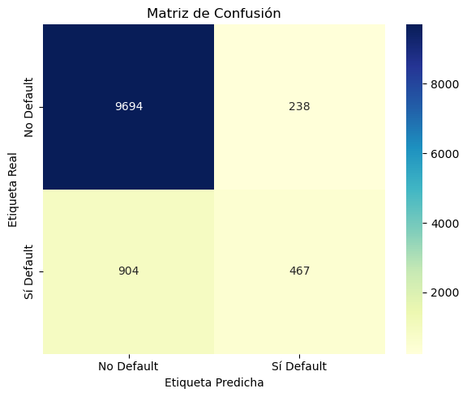

```python
# Calcular matriz
matriz = confusion_matrix(y_test, y_pred_f1)
labels = ["No Default", "Sí Default"]

# Mostrar como heatmap
plt.figure(figsize=(6, 5))
sns.heatmap(matriz, annot=True, fmt='d', cmap='YlGnBu', xticklabels=labels, yticklabels=labels)
plt.title("Matriz de Confusión")
plt.xlabel("Etiqueta Predicha")
plt.ylabel("Etiqueta Real")
plt.tight_layout()
plt.show()
```